# Menu Cost

Cheng,Tien 2023-08-22

#### 計算平均物價有上漲的店家佔總店家比例

- 蛋荒較嚴重時，有較高比例的店家物價是上漲的

| period | percentage |
| --- | --- |
| wax | 0.2871515 |
| wane | 0.2509112 |

#### wax物價上漲率之四分位值

| 0% | -1.5629639 |
| --- | --- |
| 25% | 0.0000000 |
| 50% | 0.0000000 |
| 75% | 0.0170736 |
| 100% | 1.6669364 |

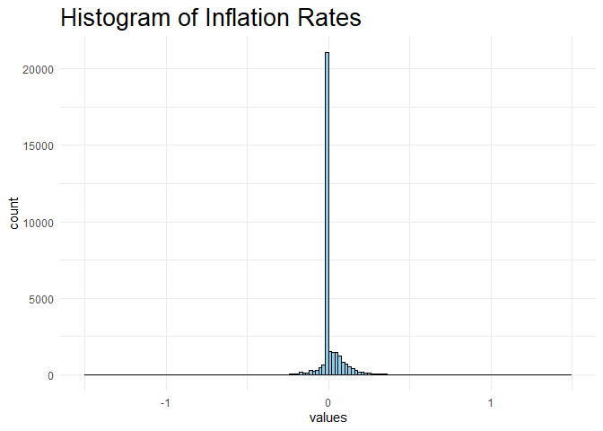

#### wane物價上漲率之四分位值

| 0% | -1.8050047 |
| --- | --- |
| 25% | 0.0000000 |
| 50% | 0.0000000 |
| 75% | 0.0016175 |
| 100% | 2.0152448 |

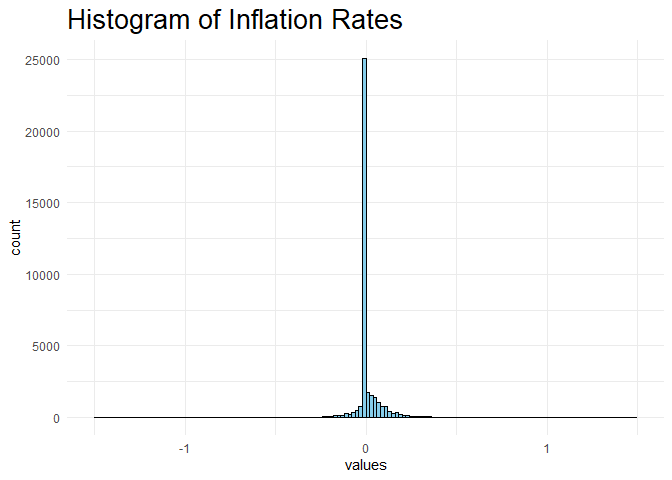

#### 蛋荒較嚴重時期

##### 一、先觀察物價上漲率大於1的店家，總共有68間

| shopCode | inflation_rate |
| --- | --- |
| lh86 | 1.666936 |
| e1iw | 1.544980 |
| m8pq | 1.513661 |
| q8sf | 1.470082 |
| seuv | 1.463255 |
| d1ls | 1.392725 |
| a1ef | 1.377926 |
| b2np | 1.377926 |
| d4hj | 1.377926 |
| i3cc | 1.377926 |
| s5te | 1.377926 |
| y0yj | 1.377926 |
| ynqu | 1.377926 |
| z4nx | 1.377926 |
| z5va | 1.377926 |
| pr81 | 1.368276 |
| b8db | 1.356694 |
| e3jc | 1.356694 |
| e7bo | 1.356694 |
| jedi | 1.356694 |
| q6yu | 1.356694 |
| lsd5 | 1.346513 |
| z7ko | 1.318491 |
| z3bf | 1.301379 |
| y2de | 1.297883 |
| y9tu | 1.297883 |
| z4wd | 1.297883 |
| a0ba | 1.297767 |
| y7lb | 1.272566 |
| y1ys | 1.270593 |
| y9yy | 1.270593 |
| a5ji | 1.251946 |
| z0zd | 1.237684 |
| cysg | 1.234744 |
| b9xu | 1.217724 |
| awvt | 1.178655 |
| o2kj | 1.163151 |
| vl3z | 1.152680 |
| pefn | 1.150135 |
| s6bd | 1.144223 |
| z2km | 1.144223 |
| lz5w | 1.140634 |
| y7ht | 1.139434 |
| p5au | 1.137979 |
| artg | 1.124208 |
| t4bt | 1.124208 |
| z9uh | 1.124208 |
| t2jb | 1.092371 |
| zmrx | 1.091177 |
| n4xa | 1.086190 |
| mi87 | 1.078410 |
| y4id | 1.060872 |
| bj3q | 1.058538 |
| tceg | 1.041160 |
| d3sc | 1.039642 |
| l0q6 | 1.039642 |
| xdj5 | 1.036009 |
| c2dr | 1.019872 |
| r2is | 1.014143 |
| u9kk | 1.005522 |
| t7wo | 1.001929 |
| d0gl | 1.000428 |
| d1sd | 1.000428 |
| e7yc | 1.000428 |
| e9ke | 1.000428 |
| l6pf | 1.000428 |
| z0rb | 1.000428 |
| z7je | 1.000428 |

##### *再取出物價上漲率最高的三間做觀察*

##### **shopcode為lh86店家**

| period | averageCost |
| --- | --- |
| before | 39.690 |
| after | 210.195 |

##### lh86店家的熱門品項

```
## $lh86
## [1] "聖選之最舒肥牛板腱餐盒" "御膳牛五花餐盒"
## [3] "滿肉饗宴牛五花燒肉丼"   "客選雙拼牛五花燒肉丼"
## [5] "御上蒲燒鰻魚餐盒"       "胡麻豆腐"
```

##### lh86店家在wane_before的菜單

```
##  [1] "特選嫩煎豚里肌餐盒" "極緻蒲燒鯛魚餐盒"   "韓式辣炒豬肉餐盒"
##  [4] "藜麥飯"             "泡菜"               "韓式豆芽菜"
##  [7] "韓式洋蔥絲"         "韓式涼拌毛豆仁"     "韓式高麗菜"
## [10] "韓式青花菜"         "胡麻洋蔥絲"         "胡麻豆腐"
## [13] "胡麻青花菜"         "海帶芽湯"           "海帶芽豆腐湯"
## [16] "澄淨碧綠高山青"     "鴻運當頭紅玉茶"     "上班搭地鐵觀音"
## [19] "清雅芬芳東方美人 "  "皇家錫蘭奶茶"       "齒留茉香奶茶"
## [22] "炭燒鐵觀音奶茶"     "皇家錫蘭珍珠奶茶"   "齒留茉香珍珠奶茶"
## [25] "炭燒鐵觀音珍珠奶茶" "零卡"               "雪碧"
## [28] "樹頂蘋果汁"         "沁涼椰子水"
```

##### lh86店家在wane_after的菜單

```
##  [1] "粉紅生乳捲"         "極緻蒲燒鯛魚餐盒"   "御上蒲燒鰻魚餐盒"
##  [4] "白飯"               "泡菜"               "韓式豆芽菜"
##  [7] "韓式洋蔥絲"         "韓式涼拌毛豆仁"     "韓式高麗菜"
## [10] "韓式青花菜"         "胡麻洋蔥絲"         "胡麻豆腐"
## [13] "胡麻青花菜"         "海帶芽湯"           "海帶芽豆腐湯"
## [16] "澄淨碧綠高山青"     "鴻運當頭紅玉茶"     "上班搭地鐵觀音"
## [19] "清雅芬芳東方美人 "  "皇家錫蘭奶茶"       "齒留茉香奶茶"
## [22] "爐火純青奶茶"       "炭燒鐵觀音奶茶"     "皇家錫蘭珍珠奶茶"
## [25] "齒留茉香珍珠奶茶"   "爐火純青珍珠奶茶"   "炭燒鐵觀音珍珠奶茶"
## [28] "可口可樂"           "零卡"               "雪碧"
```

- 可以發現在before時只有計算到[胡麻豆腐]的價格
- after則是抓取[御上蒲燒鰻魚餐盒、胡麻豆腐]的價格
- 但熱門品項[聖選之最舒肥牛板腱餐盒、御膳牛五花餐盒、滿肉饗宴牛五花燒肉丼、客選雙拼牛五花燒肉丼]並未出現在wane時期的菜單裡，我猜測這幾個品項是蛋荒較趨緩時才推出的商品

##### **shopcode為e1iw店家**

| period | averageCost |
| --- | --- |
| before | 55.0000 |
| after | 257.8333 |

##### e1iw店家的熱門品項

```
## $e1iw
## [1] "【2號餐】"      "【3號餐】"      "【4號餐】"      "【5號全家餐】"
## [5] "【腿塊混搭餐】" "波霸脆薯條(小)"
```

##### e1iw店家在wane_before的菜單

```
##  [1] "胖老爹於門市販售之點心「花雕雞香腸」及「花枝丸」皆含豬肉及豬油製品，豬肉原產地皆為台灣，請消費者安心使用。"
##  [2] "本店每筆訂單酌收餐點包裝費1元"
##  [3] "運彩足好運全家桶餐(不含飲料)"
##  [4] "運彩足好運全家桶餐(含飲料)"
##  [5] "「可口可樂」歡聚享樂套餐A"
##  [6] "1號餐"
##  [7] "2號餐"
##  [8] "3號餐"
##  [9] "4號餐"
## [10] "5號全家餐"
## [11] "5號全家餐+飲料"
## [12] "6號全家特餐"
## [13] "全腿餐"
## [14] "全塊餐"
## [15] "混搭餐"
```

[output cut: 37 more lines]

##### e1iw店家在wane_after的菜單

```
##  [1] "【1號餐】"                     "【2號餐】"
##  [3] "【3號餐】"                     "【4號餐】"
##  [5] "【5號全家餐】"                 "【5號全家餐(含飲料)】"
##  [7] "【6號全家特餐】"               "【全腿餐】"
##  [9] "【全塊餐】"                    "【腿塊混搭餐】"
## [11] "【全腿餐(含飲料)】"            "【全塊餐(含飲料)】"
## [13] "【腿塊混搭餐(含飲料)】"        "【全翅餐】"
## [15] "【全翅餐(含飲料)】"            "【紐奧良雞排餐】"
## [17] "【無骨雞腿排餐】"              "【One4如意分享餐】"
## [19] "【雞翅分享餐】"                "【雙排點心餐】"
## [21] "【雙人分享A餐】"               "【雙人分享B餐】"
## [23] "【好四成雙餐】"                "【雙雙對對萬年富貴餐】"
## [25] "【墜入愛河分享餐】"            "【腿翅分享A餐】"
## [27] "【腿翅分享B餐】"               "【小三元套餐】"
## [29] "【大三元套餐】"                "【小四喜套餐】"
```

[output cut: 21 more lines]

- 可以發現到造成價格的差異來自於品項名稱定義的不同，before的套餐皆無用【】符號。
- 假設before和after的套餐內容並無實際差別，且在before的”混搭餐”跟after的”腿塊混搭餐”是同樣商品，則抓出價格比較

| product | February | April |
| --- | --- | --- |
| 2號餐 | 140 | 150 |
| 3號餐 | 175 | 189 |
| 4號餐 | 185 | 195 |
| 5號全家餐 | 399 | 439 |
| 腿塊混搭餐 | 479 | 509 |
| 波霸脆薯條(小) | 55 | 65 |

- 可以發現到熱門品項的價格皆有上漲的趨勢，上漲的幅度大概在10元至40元不等

##### **shopcode為m8pq店家**

| period | averageCost |
| --- | --- |
| before | 60.0 |
| after | 272.6 |

##### m8pq店家的熱門品項

```
## $m8pq
## [1] "【2號餐】"      "【4號餐】"      "【5號全家餐】"  "【腿塊混搭餐】"
## [5] "雞腿"           "波霸脆薯條(小)"
```

##### m8pq店家在wane_before的菜單

```
##  [1] "胖老爹於門市販售之點心「花雕雞香腸」及「花枝丸」皆含豬肉及豬油製品，豬肉原產地皆為台灣，請消費者安心使用。"
##  [2] "本店每筆訂單酌收餐點包裝費1元"
##  [3] "1號餐"
##  [4] "2號餐"
##  [5] "3號餐"
##  [6] "4號餐"
##  [7] "5號全家餐"
##  [8] "混搭餐"
##  [9] "雞腿"
## [10] "雞塊"
## [11] "雞翅"
## [12] "胖雞丁(大)"
## [13] "紐奧良雞排"
## [14] "無骨雞腿排"
## [15] "花雕雞香腸"
```

[output cut: 21 more lines]

##### m8pq店家在wane_after的菜單

```
##  [1] "【1號餐】"                     "【2號餐】"
##  [3] "【4號餐】"                     "【5號全家餐】"
##  [5] "【5號全家餐(含飲料)】"         "【6號全家特餐】"
##  [7] "【全腿餐】"                    "【全塊餐】"
##  [9] "【腿塊混搭餐】"                "【全腿餐(含飲料)】"
## [11] "【全塊餐(含飲料)】"            "【腿塊混搭餐(含飲料)】"
## [13] "【全翅餐】"                    "【全翅餐(含飲料)】"
## [15] "雞腿"                          "雞塊"
## [17] "雞翅"                          "無骨雞腿排"
## [19] "泰式雞翅(4支)"                 "花雕雞香腸(1條)"
## [21] "黃金地瓜條(小)"                "洋蔥圈(6個)"
## [23] "花枝丸(4個)"                   "山藥捲(4條)"
## [25] "小芋泥球(6顆)"                 "黃金魷米花(1份)"
## [27] "薯餅(3片)"                     "芝麻球(4顆)"
## [29] "地瓜球(4顆)"                   "深海鱈魚條(2條)"
## [31] "奶香螺絲捲(2個)"               "小雞塊(5個)"
## [33] "披薩球(4顆)"                   "煉乳螺絲捲(2個)"
## [35] "乳酪甜心酥(4顆)"               "玉米布丁酥"
## [37] "辣椒粉(3小包)"                 "胡椒粉(3小包)"
## [39] "泰式醬(1包)"                   "可樂小寶特瓶350ml"
## [41] "雪碧小寶特瓶350ml"             "  可樂大寶特瓶1250ml"
## [43] "雪碧大寶特瓶1250ml"            "本店每筆訂單酌收餐點包裝費1元"
```

- 可以發現到這間店和第二間一樣都是胖老爹炸雞，熱門品項也大致相同（少了3號餐，多了雞腿的品項）。
- 比較特別的是熱門品項[波霸脆薯條(小)]並無出現在after的菜單裡，速食店居然會有沒賣薯條的時候。
- 一樣將它的價格取出並做比較及觀察

| product | February | April |
| --- | --- | --- |
| 2號餐 | 140 | 150 |
| 4號餐 | 185 | 195 |
| 5號全家餐 | 399 | 439 |
| 腿塊混搭餐 | 479 | 509 |
| 雞腿 | 65 | 70 |
| 波霸脆薯條(小) | 55 | NA |

- 可以發現到胖老爹熱門套餐類的漲幅都是相同的
- 由於有兩間是相同的胖老爹炸雞，但處於不同分店，再取出第四間店觀察

##### **shopcode為q8sf店家**

| period | averageCost |
| --- | --- |
| before | 41.0000 |
| after | 178.3333 |

##### q8sf店家的熱門品項

```
## $q8sf
## [1] "個人份雞肉【綜合部位】" "海帶根X2"
## [3] "A套餐：個人份雞肉5配菜" "B套餐：半隻雞4配菜"
## [5] "C套餐：半隻雞7配菜"     "水蓮菜"
```

##### q8sf店家在wane_before的菜單

```
##  [1] "半隻雞【去骨】"         "個人份雞肉【綜合部位】"
##  [3] "舒肥雞肉"               "洋蔥X2"
##  [5] "洋地瓜X2"               "海帶根X2"
##  [7] "A套餐"                  "B套餐"
##  [9] "C套餐"                  "D套餐"
## [11] "E套餐"                  "F套餐"
## [13] "高麗菜"                 "花椰菜"
## [15] "玉米筍"                 "四季豆"
## [17] "黑木耳"                 "苦瓜"
## [19] "秋葵"                   "蓮藕"
## [21] "小黃瓜"                 "洋蔥"
## [23] "海帶根"                 "馬鈴薯"
## [25] "龍鬚菜"                 "金針菇"
## [27] "杏鮑菇"                 "筍片"
## [29] "小香菇"                 "水蓮菜"
## [31] "洋地瓜"                 "豆芽菜"
## [33] "大豆干"                 "小豆干"
## [35] "米血"                   "甜不辣"
## [37] "鳥蛋"                   "百頁豆腐"
## [39] "豆皮"                   "魚板豆腐"
## [41] "煙燻豬頭皮"             "柴魚白蘿蔔"
## [43] "蜜糖紅蘿蔔"             "黑輪"
## [45] "小貢丸"                 "滷海帶"
## [47] "雞腸"                   "雞屁股"
## [49] "雞蛋黃"                 "雞心"
## [51] "雞胗"                   "雞冠"
## [53] "雞皮"                   "鹹度選擇"
## [55] "口味選擇"               "不加料選擇"
```

##### q8sf店家在wane_after的菜單

```
##  [1] "半隻雞【去骨】"         "個人份雞肉【綜合部位】"
##  [3] "舒肥雞肉"               "洋蔥X2"
##  [5] "洋地瓜X2"               "海帶根X2"
##  [7] "A套餐：個人份雞肉5配菜" "B套餐：半隻雞4配菜"
##  [9] "C套餐：半隻雞7配菜"     "D套餐：半隻雞11配菜"
## [11] "E套餐：全雞10樣菜"      "F套餐：全雞14樣配菜"
## [13] "高麗菜"                 "花椰菜"
## [15] "玉米筍"                 "四季豆"
## [17] "黑木耳"                 "苦瓜"
## [19] "秋葵"                   "小黃瓜"
## [21] "洋蔥"                   "海帶根"
## [23] "馬鈴薯"                 "龍鬚菜"
## [25] "金針菇"                 "杏鮑菇"
## [27] "筍片"                   "小香菇"
## [29] "水蓮菜"                 "洋地瓜"
## [31] "豆芽菜"                 "大溪黑豆乾"
## [33] "小豆干"                 "米血糕"
## [35] "甜不辣"                 "百頁豆腐"
## [37] "豆皮"                   "魚板豆腐"
## [39] "超薄豬頭皮"             "柴魚白蘿蔔"
## [41] "蜜糖紅蘿蔔"             "黑輪"
## [43] "小貢丸"                 "滷海帶"
## [45] "雞屁股"                 "雞心"
## [47] "雞胗"                   "雞皮"
## [49] "鹹度選擇"               "口味選擇"
## [51] "不加料選擇"
```

- 可以觀察到造成物價上漲的原因也是來自於品項定義的不同，在before的名稱裡並無詳述餐點內容，但在after的套餐裡有詳細說明，如[ A套餐：個人份雞肉5配菜、B套餐：半隻雞4配菜、C套餐：半隻雞7配菜]
- 假設套餐組合的內容物相同，取出價格比較

| product | February | April |
| --- | --- | --- |
| 個人份雞肉【綜合部位】 | 70 | 80 |
| 海帶根X2 | 25 | 25 |
| A套餐：個人份雞肉5配菜 | 210 | 225 |
| B套餐：半隻雞4配菜 | 280 | 310 |
| C套餐：半隻雞7配菜 | 360 | 395 |
| 水蓮菜 | 28 | 35 |

- 套餐類皆漲15至35元不等，而水蓮菜的漲幅來到了25%，上漲的幅度驚人

##### 小結

- 會有超過100%的成本上漲率，第一個原因來自於菜單內容的改變，前期還未推出的產品在後期推出，會形成計算平均價格的差異；而第二個原因來自於品項名稱定義的差異，在這種情形前後期菜單是相同的，但在命名上的不同會造成before沒抓到熱門品項而after有抓到，形成平均價格差異甚大的狀況。但第二種情形還能用觀察的再抓出價格做比較

##### 二、觀察物價上漲率小於-1的店家，總共有4間

|  | shopCode | inflation_rate |
| --- | --- | --- |
| uvrf | uvrf | -1.562964 |
| wdl7 | wdl7 | -1.386294 |
| j0ev | j0ev | -1.252763 |
| r8ws | r8ws | -1.206193 |

##### 觀察是否跟前一章節相同，是因為品項名稱定義造成

##### **shopcode為uvrf店家**

| period | averageCost |
| --- | --- |
| before | 329.3333 |
| after | 69.0000 |

##### uvrf店家的熱門品項

```
## $uvrf
## [1] "鹽之花可頌 X2"      "北海道原味生乳包"   "白吐司"
## [4] "黑森林蛋糕【六吋】" "冰黑咖啡"           "冰拿鐵"
```

##### uvrf店家在wane_before的菜單

```
##   [1] "艾許奶酥"                        "艾許菠蘿"
##   [3] "鹽之花可頌"                      "艾許流沙菠蘿包"
##   [5] "雲朵生吐司"                      "芋花園小蛋糕"
##   [7] "巧克森林小蛋糕"                  "冰火菠蘿"
##   [9] "芋泥菠蘿包"                      "熊掌包"
##  [11] "沙拉肉鬆麵包"                    "蔥仔胖"
##  [13] "全麥肉鬆餐包"                    "花生菠蘿夾心麵包"
##  [15] "維也納"                          "鹹奶油波蘿麵包"
##  [17] "日式紅豆麵包"                    "起酥肉脯麵包"
##  [19] "奶油捲麵包"                      "椰子奶酥"
##  [21] "花生捲捲"                        "辣醬德腸"
##  [23] "黑眼豆豆麵包"                    "德國香蒜麵包"
##  [25] "奶香包"                          "甜甜圈"
##  [27] "草莓甜甜圈"                      "丹麥藍莓"
##  [29] "丹麥巧克力菠蘿"                  "紫米桂圓核桃"
```

[output cut: 48 more lines]

##### uvrf店家在wane_after的菜單

```
##  [1] "艾許菠蘿"                        "芋花園小蛋糕"
##  [3] "冰火菠蘿"                        "草莓甜甜圈"
##  [5] "萌萌鹿異想世界【升級款 | 6吋】"  "小小怪手王【升級款 | 6吋】"
##  [7] "月光慶典C【升級款 | 6吋】"       "幸運之花蛋糕【六吋】"
##  [9] "雅典娜蛋糕【六吋】"              "黑森林蛋糕【八吋】"
## [11] "芋到愛蛋糕【八吋】"              "水果樂園蛋糕【八吋】"
## [13] "冰黑咖啡"                        "冰拿鐵"
## [15] "冰焦糖瑪奇朵"                    "冰榛果提拉拿鐵"
## [17] "冰重乳拿鐵"                      "冰玫瑰拿鐵"
## [19] "冰經典左岸拿鐵"                  "熱黑咖啡"
## [21] "熱拿鐵"                          "熱焦糖瑪奇朵"
## [23] "熱榛果提拉拿鐵"                  "熱重乳拿鐵"
## [25] "熱玫瑰拿鐵"                      "熱經典左岸拿鐵"
## [27] "冰翡翠金萱"                      "冰四季春"
## [29] "冰日月潭紅玉"                    "冰碳焙烏龍"
```

[output cut: 24 more lines]

- 可以看出[黑森林蛋糕【六吋】]只出現在before的菜單裡，after只有八吋的黑森林蛋糕，而整模的蛋糕屬於菜單裡較高單價的商品(六吋黑森林蛋糕850、八吋黑森林蛋糕1063)，會使before的平均物價高出許多

##### **shopcode為wdl7店家**

| period | averageCost |
| --- | --- |
| before | 140 |
| after | 35 |

##### wdl7店家的熱門品項

```
## $wdl7
## [1] "香酥豬排餐盒（炸）"   "滷控肉餐盒"           "香酥雞排餐盒（炸）"
## [4] "卡拉雞餐盒(炸)"       "香酥雞排（單點）"     "旗魚黑輪包蛋（單點）"
```

##### wdl7店家在wane_before的菜單

```
##  [1] "梅干控肉餐盒"         "香酥雞排餐盒（炸）"   "旗魚黑輪（包蛋）餐盒"
##  [4] "MoMo百元餐盒"         "愛吃菜餐盒"           "香酥雞排"
##  [7] "香酥豬排"             "旗魚黑輪（包蛋）"     "椰香奶酥厚片（甜）"
## [10] "香蒜厚片（鹹）"       "抹茶厚片（甜）"       "細滑花生厚片（甜）"
## [13] "顆粒花生厚片（鹹）"   "巧克力厚片（甜）"     "芋頭奶酥厚片【甜】"
## [16] "布丁奶酥厚片【甜】"   "純奶酥厚片（甜）"     "可樂"
## [19] "雪碧"
```

##### wdl7店家在wane_after的菜單

```
##  [1] "瓜仔肉餐盒M"        "香酥雞排（單點）"   "香酥豬排(單點）"
##  [4] "天婦羅炸蝦（單點）" "SOSO小資輕食套餐"   "巧克力厚片（甜）"
##  [7] "椰香奶酥厚片（甜）" "抹茶厚片（甜）"     "細滑花生厚片（甜）"
## [10] "顆粒花生厚片（鹹）" "香蒜厚片（鹹）"     "布丁奶酥厚片【甜】"
## [13] "芋頭奶酥厚片【甜】" "純奶酥厚片（甜）"   "可樂"
## [16] "雪碧（檸檬風味）"
```

- before和after的菜單有些許不同，而after又只抓取到[香酥雞排（單點）]的資料。想比較這個品項在前後期的價格，但發現如果以[香酥雞排]這個名稱對應，before的價格是50元而after是35元，有點好奇一般店家會一次降15元嗎？（還是內容物不同？）

| item | price |
| --- | --- |
| 香酥雞排 | 50 |
| 香酥雞排（單點） | 35 |

##### **shopcode為j0ev店家**

| period | averageCost |
| --- | --- |
| before | 105 |
| after | 30 |

##### j0ev店家的熱門品項

```
## $j0ev
## [1] "招牌咖哩飯" "麻婆豆腐飯" "日式燒肉飯" "手工豆漿"
```

##### j0ev店家在wane_before的菜單

```
## [1] "招牌咖哩飯"   "滷肉飯便當"   "麻婆豆腐飯"   "泡菜豬肉丼飯"
## [5] "豬肉丼飯"     "日式燒肉飯"   "手工豆漿"     "奶茶"
```

##### j0ev店家在wane_after的菜單

```
## [1] "鮮肉水煎包"   "韭菜水煎包"   "高麗菜水煎包" "手工豆漿"
## [5] "奶茶"
```

- 此間店前後的商品差距甚大，不禁好奇這是哪間店？只有飲料的部分前後期相同，主食方面菜單大改。

##### **shopcode為r8ws店家**

| period | averageCost |
| --- | --- |
| before | 150.3333 |
| after | 45.0000 |

##### r8ws店家的熱門品項

```
## $r8ws
## [1] "港式凍檸茶X2"              "招牌家傳牛肉麵 日式拉麵"
## [3] "招牌家傳牛肉麵 手工刀削麵" "清燉牛肉麵 日式拉麵"
## [5] "清燉牛肉麵 手工刀削麵"
```

##### r8ws店家在wane_before的菜單

```
##  [1] "港式凍檸茶X2"                    "清燉牛肉湯麵【無肉】日式拉麵"
##  [3] "紅燒牛肉湯麵【無肉】日式拉麵"    "清燉牛肉湯麵【無肉】手工刀削麵"
##  [5] "紅燒牛肉湯麵【無肉】手工刀削麵"  "清燉牛肉麵 日式拉麵"
##  [7] "清燉牛肉麵 手工刀削麵"           "凍檸茶"
##  [9] "凍檸樂"                          "凍檸七"
## [11] "冰絲襪奶茶"                      "冰鴛鴦奶茶"
## [13] "本店每筆訂單酌收餐點包裝費1元。"
```

##### r8ws店家在wane_after的菜單

```
## [1] "港式凍檸茶X2"                    "胡麻玉米筍"
## [3] "胡麻花椰菜"                      "凍檸茶"
## [5] "凍檸樂"                          "凍檸七"
## [7] "冰絲襪奶茶"                      "冰鴛鴦奶茶"
## [9] "本店每筆訂單酌收餐點包裝費1元。"
```

- after的菜單裡主食都消失了，只剩飲料部分還存在

#### 蛋荒較趨緩時期

##### 一、先觀察物價上漲率大於1的店家，總共有20間

| shopCode | inflation_rate |
| --- | --- |
| k5al | 2.015245 |
| w88l | 1.937942 |
| kccq | 1.394327 |
| r8ws | 1.360407 |
| vd0e | 1.324292 |
| l37o | 1.303895 |
| wdl7 | 1.280934 |
| il9w | 1.264462 |
| jg2r | 1.243582 |
| edqs | 1.238401 |
| j05a | 1.176179 |
| wp6x | 1.167169 |
| cii4 | 1.143374 |
| dgj1 | 1.140915 |
| cf1p | 1.120591 |
| v3nv | 1.069150 |
| jz50 | 1.059472 |
| chpw | 1.040343 |
| z1xk | 1.029619 |
| pb2n | 1.023939 |

##### *再取出物價上漲率最高的三間做觀察*

##### **shopcode為k5al店家**

| period | averageCost |
| --- | --- |
| before | 39.0 |
| after | 292.6 |

##### k5al店家的熱門品項

```
## $k5al
## [1] "熟成嫩肩牛排300gミスジ Blade steak"
## [2] "熟成骰子牛200gサイコロ牛 Diced beef steak"
## [3] "熟成骰子牛300gサイコロ牛 Diced beef steak"
## [4] "起司漢堡排Hamburg"
## [5] "豬排250g/豚ステーキpork chop"
## [6] "馬鈴薯沙拉"
```

##### k5al店家在wane_before的菜單

```
##  [1] "熟成嫩肩牛排300g"          "安格斯混切骰子牛200g"
##  [3] "安格斯混切骰子牛300g"      "舒肥雞腿排"
##  [5] "蔥鹽牛舌(薄切）100g"       "熟成嫩肩牛排200g"
##  [7] "安格斯混切骰子牛（500g)"   "安格斯肋眼心300g"
##  [9] "特上熟成嫩肩牛排200g"      "安格斯翼板牛排200g"
## [11] "安格斯翼板牛排300g"        "特製漢堡排(牛）"
## [13] "豬排"                      "香煎鯖魚"
## [15] "黑胡椒牛肉蓋飯"            "蝦多多蓋飯"
## [17] "咖哩牛肉蓋飯"              "白飯"
## [19] "溫泉卵"                    "蔥鹽四倍量"
## [21] "日式滷蛋"                  "鐵板蛋"
## [23] "例湯"                      "時蔬（胡麻龍鬚菜）"
## [25] "香煎干貝（2顆）"           "溫泉卵+時蔬（胡麻龍鬚菜）"
## [27] "溫泉卵+馬鈴薯沙拉"         "馬鈴薯沙拉"
## [29] "香煎蝦仁（3隻）"           "香煎蝦仁（6隻）"
## [31] "岩海苔"                    "炸蒜片"
```

##### k5al店家在wane_after的菜單

```
##  [1] "熟成嫩肩牛排300gミスジ Blade steak"
##  [2] "熟成骰子牛200gサイコロ牛 Diced beef steak"
##  [3] "熟成骰子牛300gサイコロ牛 Diced beef steak"
##  [4] "舒肥雞腿排/雞もも肉sous vide thigh"
##  [5] "薄切蔥鹽牛舌150g薄切りタン beef tongue"
##  [6] "熟成嫩肩牛排200gミスジ Blade steak"
##  [7] "熟成骰子牛500gサイコロ牛 Diced beef steak"
##  [8] "安格斯肋眼心牛排300gリブ芯"
##  [9] "特上熟成嫩肩牛排200g特上ミスジ Blade steak"
## [10] "豬排250g/豚ステーキpork chop"
## [11] "牛肩小排200g Short rib boneless"
## [12] "特上厚切牛舌150g厚切りタンBeef Tongue"
## [13] "特上熟成嫩肩牛排300g特上ミスジ Blade steak"
## [14] "深海大魷魚/イカsquid"
## [15] "黑牛燒肉便當"
```

[output cut: 21 more lines]

- 可以發現到在after的菜單裡除了中文以外還加入了日文及英文，造成抓取品項名稱的差異
- 取出前後期價格來比較

| product | April | July |
| --- | --- | --- |
| 熟成嫩肩牛排300gミスジ Blade steak | 438 | 438 |
| 熟成骰子牛200gサイコロ牛 Diced beef steak | 328 | 328 |
| 熟成骰子牛300gサイコロ牛 Diced beef steak | 438 | 438 |
| 起司漢堡排Hamburg | NA | NA |
| 豬排250g/豚ステーキpork chop | 220 | 220 |
| 馬鈴薯沙拉 | 39 | 39 |

- 假設before的[安格斯混切骰子牛]就是after的[熟成骰子牛]，比較前後期差異可以發現到這間店的價格其實沒有調漲

##### **shopcode為w88l店家**

| period | averageCost |
| --- | --- |
| before | 45.0 |
| after | 312.5 |

##### w88l店家的熱門品項

```
## $w88l
## [1] "聰明洛梅飲"               "可口可樂"
## [3] "中包菜(半熟)加魚肉"       "大沙鍋菜(半熟)加中頭加肉"
## [5] "大菜【半熟】加中鰱魚頭"   "大沙鍋菜(半熟)加魚肉"
```

##### w88l店家在wane_before的菜單

```
##  [1] "沙鍋菜魚肉套餐"
##  [2] "沙鍋菜套餐"
##  [3] "沙鍋菜冬粉、紅茶"
##  [4] "冷凍沙鍋菜"
##  [5] "沙鍋菜(不含魚)"
##  [6] "沙鍋菜加魚肉"
##  [7] "沙鍋菜、冬粉"
##  [8] "沙鍋菜、烏龍麵"
##  [9] "白飯"
## [10] "雞肉飯"
## [11] "太陽蛋滷肉飯"
## [12] "滷肉飯"
## [13] "古早味紅茶"
## [14] "聰明洛梅飲"
## [15] "清冬粉"
## [16] "大沙鍋菜"
## [17] "中沙鍋菜"
## [18] "小沙鍋菜"
## [19] "中鰱魚頭"
## [20] "魚肉"
## [21] "1.本店每筆訂單酌收餐點包裝費2元    2.如勾選不需要免洗餐具則不附碗    3.本店皆使用台灣豬肉，非基改豆腐、豆皮、蔥、洋蔥、辣椒、白菜"
```

##### w88l店家在wane_after的菜單

```
## [1] "1.本店每筆訂單酌收餐點包裝費2元    2.如勾選不需要免洗餐具則不附碗    3.本店皆使用台灣豬肉，非基改豆腐、豆皮、蔥、洋蔥、辣椒、白菜"
## [2] "古早味紅茶"
## [3] "聰明洛梅飲"
## [4] "可口可樂"
## [5] "中包菜(半熟)加魚肉"
## [6] "大沙鍋菜(半熟)加中頭加肉"
## [7] "大菜【半熟】加中鰱魚頭"
## [8] "大沙鍋菜(半熟)加魚肉"
```

- 可以發現這間店的前後期商品內容物不盡相同，before是以大、中、小沙鍋菜販售，after則是除了沙鍋菜外有加入其他肉品做綁售，此間店家的前後期價格較難以同一標準做比較。

##### **shopcode為kccq店家**

| period | averageCost |
| --- | --- |
| before | 55.8 |
| after | 225.0 |

##### kccq店家的熱門品項

```
## $kccq
## [1] "(8葷12素)小鮮肉麻辣拌(乾拌)" "(8葷12素)小鮮肉麻辣燙(好湯)"
## [3] "(3葷12素)小仙女麻辣拌(乾拌)" "麻辣鴨血"
## [5] "涼皮"                        "三合一湯"
```

##### kccq店家在wane_before的菜單

```
##  [1] "小鮮肉麻辣燙"         "小仙女麻辣燙"         "雙椒麻辣燙"
##  [4] "麻辣鴨血"             "滷肉飯便當(附溏心蛋)" "彩盒涼皮(葷)"
##  [7] "滷肉飯"               "椒香滷肉飯"           "花椒麻辣燙"
## [10] "藤椒麻辣燙"           "涼皮"                 "涼皮（斤）"
## [13] "涼麵【中】"           "涼麵【大】"           "彩盒涼麵(葷)"
## [16] "香辣涼皮鍋"           "札幌味噌鍋"           "韓式泡菜鍋"
## [19] "川香銷魂湯麵"         "札幌味噌湯麵"         "韓式泡菜湯麵"
## [22] "味噌湯"               "味噌蛋"               "味噌貢丸"
## [25] "三合一湯"             "方塊豆干"             "韓國泡菜"
## [28] "涼拌黃瓜"             "涼拌黑木耳"           "百香果冰粉"
## [31] "檸檬冰粉"
```

##### kccq店家在wane_after的菜單

```
##  [1] "(8葷12素)小鮮肉麻辣拌(乾拌)" "(8葷12素)小鮮肉麻辣燙(好湯)"
##  [3] "(3葷12素)小仙女麻辣拌(乾拌)" "(3葷12素)小仙女麻辣燙(好湯)"
##  [5] "方塊豆干"                    "韓國泡菜"
##  [7] "涼拌黃瓜"                    "涼拌黑木耳"
##  [9] "百香果冰粉"                  "檸檬冰粉"
```

- 可以發現這間店也是因為命名上的差異造成物價上漲率之高，比較兩者價格

| product | April | July |
| --- | --- | --- |
| (8葷12素)小鮮肉麻辣拌(乾拌) | NA | 235 |
| (8葷12素)小鮮肉麻辣燙(好湯) | 152.1 | 235 |
| (3葷12素)小仙女麻辣拌(乾拌) | NA | 205 |
| 麻辣鴨血 | 45.0 | NA |
| 涼皮 | 72.9 | NA |
| 三合一湯 | 49.5 | NA |

- 前後期菜單有改變，唯一在前後期都有的商品是[小鮮肉麻辣燙]，但漲了83元，讓我好奇兩個品項名稱雖然一樣但內容物是否不同？

##### 二、觀察物價上漲率小於-1的店家，總共有11間

| shopCode | inflation_rate |
| --- | --- |
| u1r2 | -1.805005 |
| we7f | -1.582409 |
| d1ls | -1.494508 |
| cysg | -1.293129 |
| pv5o | -1.273706 |
| wegr | -1.259543 |
| alib | -1.258040 |
| b5cu | -1.168680 |
| yrcc | -1.140915 |
| y1nj | -1.089684 |
| b5vu | -1.054621 |

##### **shopcode為u1r2店家**

| period | averageCost |
| --- | --- |
| before | 182.4 |
| after | 30.0 |

##### u1r2店家的熱門品項

```
## $u1r2
## [1] "泰式打抛雞套餐"     "蒜香台灣豬肉片套餐" "法式水煮嫩雞胸套餐"
## [4] "義國風情雞腿排套餐" "阿嬤的滷牛腱心套餐" "13香滷蛋【1顆】"
```

##### u1r2店家在wane_before的菜單

```
##  [1] "泰式打抛雞套餐"               "蒜香台灣豬肉片套餐"
##  [3] "法式水煮嫩雞胸套餐"           "地中海烤食蔬套餐"
##  [5] "匈牙利辣烤雞胸套餐"           "義國風情雞腿排套餐"
##  [7] "阿嬤的滷牛腱心套餐"           "挪威鹽烤鯖魚套餐"
##  [9] "清爽雞肉套餐"                 "清爽豬肉套餐"
## [11] "泰式雞豬套餐"                 "泰式雞情套餐"
## [13] "海陸大餐套餐"                 "十穀飯【1碗】"
## [15] "地瓜【1份】"                  "青菜【1份】"
## [17] "溏心蛋【1顆】"                "冷泡茶【1瓶 | 甜度冰量固定】"
```

##### u1r2店家在wane_after的菜單

```
## [1] "十穀飯【1碗】"                "地瓜【1塊】"
## [3] "青菜【1份】"                  "13香滷蛋【1顆】"
## [5] "冷泡茶【1瓶 | 甜度冰量固定】"
```

- after的菜單裡只剩配菜及飲料，主食皆無出現，難以比較前後期價格差異

##### **shopcode為we7f店家**

| period | averageCost |
| --- | --- |
| before | 146 |
| after | 30 |

##### we7f店家的熱門品項

```
## $we7f
## [1] "明爐燒鴨"   "雙囍臨門"   "三寶惦記"   "玫瑰油雞腿" "四大天王"
## [6] "冰紅茶"
```

##### we7f店家在wane_before的菜單

```
##  [1] "明爐燒鴨"         "雙囍臨門"         "三寶惦記"
##  [4] "金牌香腸"         "蜜汁叉燒"         "脆皮燒肉"
##  [7] "玫瑰油雞腿"       "四大天王"         "五樣都來"
## [10] "叉燒肉【一斤】"   "蔥油"             "半隻鴨"
## [13] "白飯"             "雞腿"             "滷蛋"
## [16] "辣椒醬油"         "新鮮的鹹蛋"       "脆皮燒肉【一斤】"
## [19] "香腸【半斤】"     "鴨頭"
```

##### we7f店家在wane_after的菜單

```
##  [1] "蔥油"             "半隻鴨"           "白飯"
##  [4] "雞腿"             "辣椒醬油"         "新鮮的鹹蛋"
##  [7] "脆皮燒肉【一斤】" "香腸【半斤】"     "鴨頭"
## [10] "冰紅茶"
```

- 前後期菜單有些許不同，但比較兩期皆有的主食[半隻鴨]，價格皆為800，並無作價格上的調整

##### **shopcode為d1ls店家**

| period | averageCost |
| --- | --- |
| before | 312 |
| after | 70 |

##### d1ls店家的熱門品項

```
## $d1ls
## [1] "6入甜甜圈"      "10入甜甜圈"     "檸檬優格波堤"   "檸檬蜜糖波堤\n"
## [5] "哞~草莓牛奶"    "皇家伯爵茶歐蕾"
```

##### d1ls店家在wane_before的菜單

```
##  [1] "如果選擇品項售完，由夥伴隨機幫您挑選喔！"
##  [2] "圖片僅供參考，依實際門市提供餐點為主。"
##  [3] "如對訂單有任何疑問，請與外送平台客服聯繫，謝謝！"
##  [4] "優惠餐組數量有限，售完為止；無法點購即本日結束。"
##  [5] "本店使用豬肉之原產地：台灣"
##  [6] "6入甜甜圈"
##  [7] "10入甜甜圈"
##  [8] "歡樂派對"
##  [9] "一〇八抹茶茶廊豆香抹茶生波堤\\n"
## [10] "一〇八抹茶茶廊雙層豆香抹茶生波堤\\n"
## [11] "一〇八抹茶茶廊蜜糖抹茶波堤\\n"
## [12] "蜜糖波堤"
## [13] "雙層巧克力波堤"
## [14] "草莓波堤"
## [15] "草莓巧克力波堤"
```

[output cut: 16 more lines]

##### d1ls店家在wane_after的菜單

```
##  [1] "如果選擇品項售完，由夥伴隨機幫您挑選喔！"
##  [2] "圖片僅供參考，依實際門市提供餐點為主。"
##  [3] "如對訂單有任何疑問，請與外送平台客服聯繫，謝謝！"
##  [4] "優惠餐組數量有限，售完為止；無法點購即本日結束。"
##  [5] "本店使用豬肉之原產地：台灣 本店使用牛肉之原產地：巴拉圭"
##  [6] "哞~愛文芒果牛奶 \\u3000"
##  [7] "翡翠檸檬青茶\\n"
##  [8] "蜂蜜檸檬飲\\n"
##  [9] "愛文芒果可爾必思氣泡\\n"
## [10] "熱琥珀烏龍茶"
## [11] "摩卡珈琲"
## [12] "可可伯爵茶歐蕾"
## [13] "卡布奇諾"
## [14] "「可爾必思」"
## [15] "台灣無糖青茶"
## [16] "美式珈琲"
## [17] "拿鐵珈琲"
## [18] "皇家伯爵紅茶"
## [19] "蜂蜜桔子茶"
## [20] "蘋果紅茶"
## [21] "皇家伯爵茶歐蕾"
```

- 由品項名稱可以猜測此間店應該是賣甜甜圈及飲料的店家，但在after的菜單並無出現任何甜甜圈的品項，有可能是品項已售完？

#### 細分persistent_popularItems_count的型態

```
## persistent_popularItems_count
##     0     1     2     3     4     5     6
##  2720   835  1644  2274  3491  6366 17710
```

##### **以是否為正餐來討論**

##### 在三期中產品名稱相同的店家，販售正餐的比例

[output not shown]

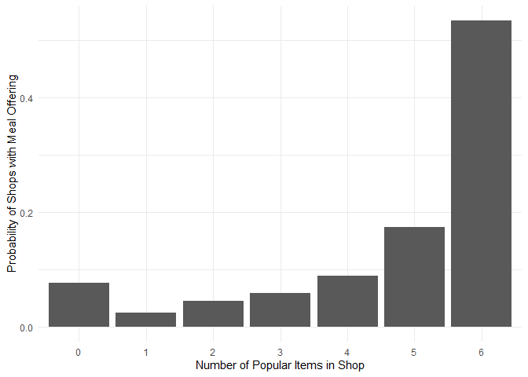

##### **以營業時段來討論**

##### 六個品項的店家當中的營業時間分布

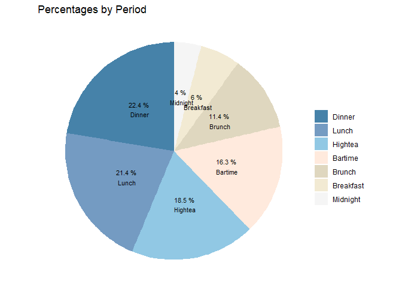

##### 五個品項的店家當中的營業時間分布

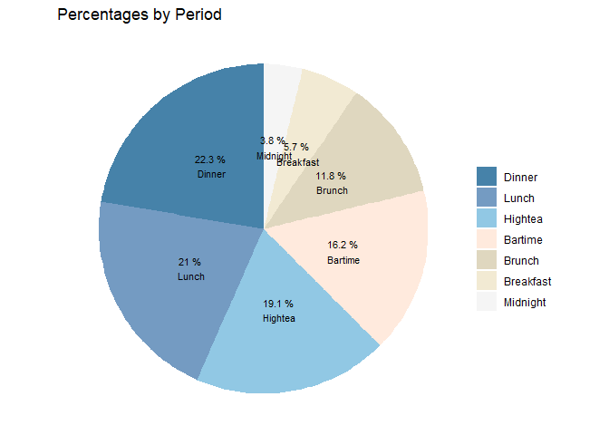

##### 四個品項的店家當中的營業時間分布

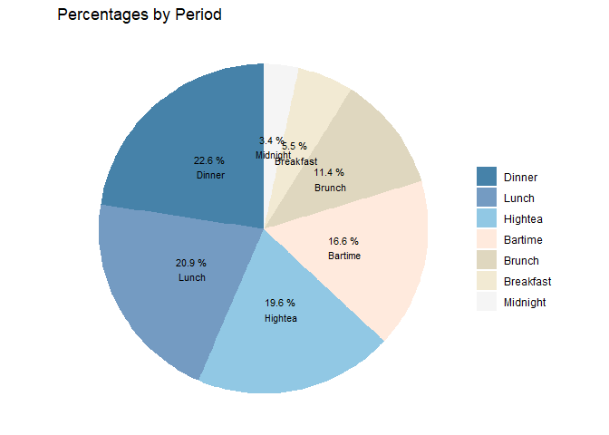

##### 三個品項的店家當中的營業時間分布

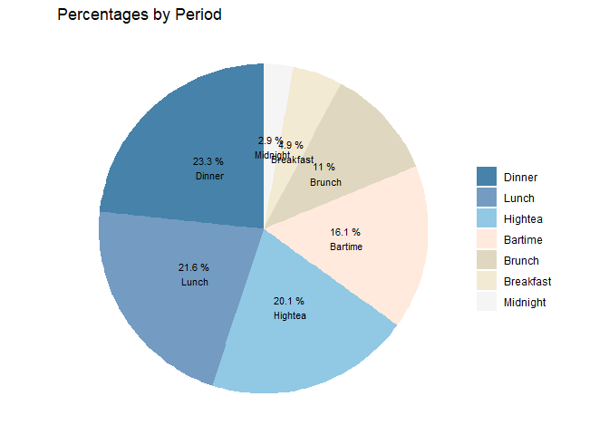

##### 二個品項的店家當中的營業時間分布

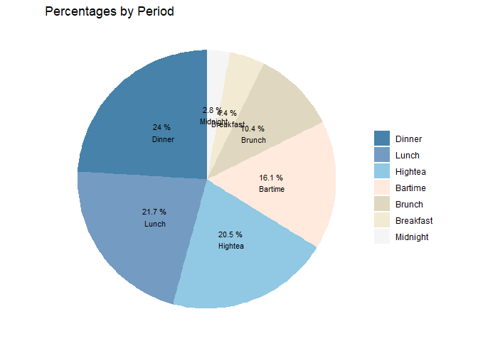

##### 一個品項的店家當中的營業時間分布

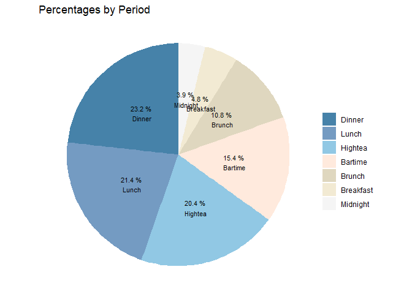

##### 零個品項的店家當中的營業時間分布

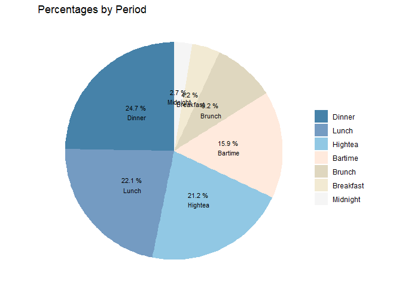

##### 選出在breakfast、lunch、dinner提供正餐的shopcode名單

| business_hour | numberOfShop |
| --- | --- |
| breakfast | 6224 |
| lunch | 23229 |
| dinner | 24814 |

##### 選出在breakfast、lunch、dinner提供正餐且持續6項的shopcode名單

| business_hour | numberOfShop |
| --- | --- |
| breakfast | 3514 |
| lunch | 12398 |
| dinner | 12954 |

#### 以持續六項且供應正餐的店家作討論

|  | (-Inf,-0.2] | (-0.2,-0.1] | (-0.1,0] | 0 | (0,0.1] | (0.1,0.2] | (0.2,Inf] | mean_inflationRates |
| --- | --- | --- | --- | --- | --- | --- | --- | --- |
| summary_cpi_wax | 35 | 107 | 137 | 11469 | 2626 | 730 | 148 | 0.0150506 |
| summary_cpi_wane | 27 | 79 | 157 | 12579 | 1791 | 519 | 100 | 0.0102684 |

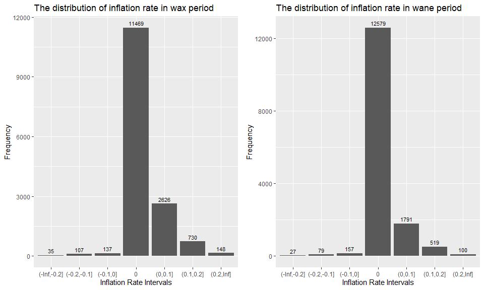

- 從圖中可以發現到，在蛋荒嚴重時有11469間店家是物價上漲率為0(以2月3日為前期,4月27日為後期)，而在蛋荒趨緩時增為12579間店家(以4月27日為前期,7月26日為後期)，且在蛋荒趨緩時，物價上漲率大於0的店家數量有減少的趨勢。

##### 以城市分類並計算CPI

###### 以wax時期高至低排序

| county | CPI_wax | CPI_wane |
| --- | --- | --- |
| 澎湖縣 | 0.0215527 | 0.0005120 |
| 花蓮縣 | 0.0198006 | 0.0104436 |
| 桃園市 | 0.0192837 | 0.0094564 |
| 嘉義縣 | 0.0182182 | 0.0099024 |
| 臺中市 | 0.0178917 | 0.0112926 |
| 苗栗縣 | 0.0178311 | 0.0090640 |
| 宜蘭縣 | 0.0174885 | 0.0106448 |
| 新竹市 | 0.0173784 | 0.0097222 |
| 彰化縣 | 0.0164648 | 0.0097770 |
| 新竹縣 | 0.0158071 | 0.0111707 |
| 基隆市 | 0.0148777 | 0.0095115 |
| 南投縣 | 0.0147994 | 0.0128719 |
| 臺南市 | 0.0142355 | 0.0093070 |
| 屏東縣 | 0.0137331 | 0.0113882 |
| 新北市 | 0.0136278 | 0.0117989 |
| 雲林縣 | 0.0133700 | 0.0097215 |
| 臺北市 | 0.0131325 | 0.0090395 |
| 嘉義市 | 0.0129521 | 0.0079991 |
| 臺東縣 | 0.0119489 | 0.0201091 |
| 高雄市 | 0.0112796 | 0.0100340 |
| 金門縣 | 0.0012108 | 0.0114028 |

###### 以wane時期高至低排序

| county | CPI_wax | CPI_wane |
| --- | --- | --- |
| 臺東縣 | 0.0119489 | 0.0201091 |
| 南投縣 | 0.0147994 | 0.0128719 |
| 新北市 | 0.0136278 | 0.0117989 |
| 金門縣 | 0.0012108 | 0.0114028 |
| 屏東縣 | 0.0137331 | 0.0113882 |
| 臺中市 | 0.0178917 | 0.0112926 |
| 新竹縣 | 0.0158071 | 0.0111707 |
| 宜蘭縣 | 0.0174885 | 0.0106448 |
| 花蓮縣 | 0.0198006 | 0.0104436 |
| 高雄市 | 0.0112796 | 0.0100340 |
| 嘉義縣 | 0.0182182 | 0.0099024 |
| 彰化縣 | 0.0164648 | 0.0097770 |
| 新竹市 | 0.0173784 | 0.0097222 |
| 雲林縣 | 0.0133700 | 0.0097215 |
| 基隆市 | 0.0148777 | 0.0095115 |
| 桃園市 | 0.0192837 | 0.0094564 |
| 臺南市 | 0.0142355 | 0.0093070 |
| 苗栗縣 | 0.0178311 | 0.0090640 |
| 臺北市 | 0.0131325 | 0.0090395 |
| 嘉義市 | 0.0129521 | 0.0079991 |
| 澎湖縣 | 0.0215527 | 0.0005120 |

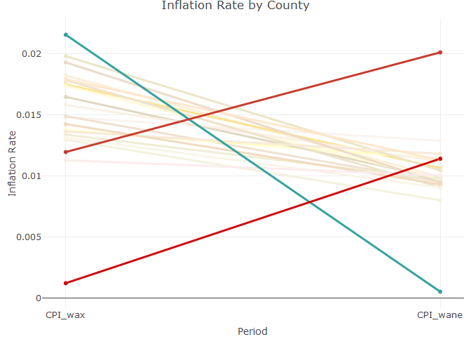

- 從wax到wane時期，只有臺東縣和金門縣的走勢是向上，其餘縣市則是下降，想特別探討這兩個縣市的菜單價格變化。另外一點，澎湖縣在wax時期的物價上漲率在2.16%左右，但在wane時期有劇烈下降幅度，降至0.0512%，是剛好在2/3至4/27這段期間多數店家菜單價格都剛好調漲嗎?
- 圖形說明:將上漲的縣市以紅色系標示，劇烈下跌之縣市用綠色標示

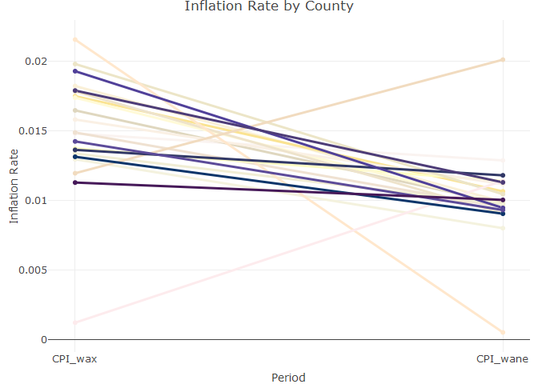

- 特別標示出直轄市與其他縣市作比較，蛋荒嚴重時期，物價上漲率在前十名的直轄市只有桃園市及台中市，分別排在第三及第五名。但在蛋荒趨緩時期，新北市從15名躍升至第3名，高雄市也從20名升至第10名。

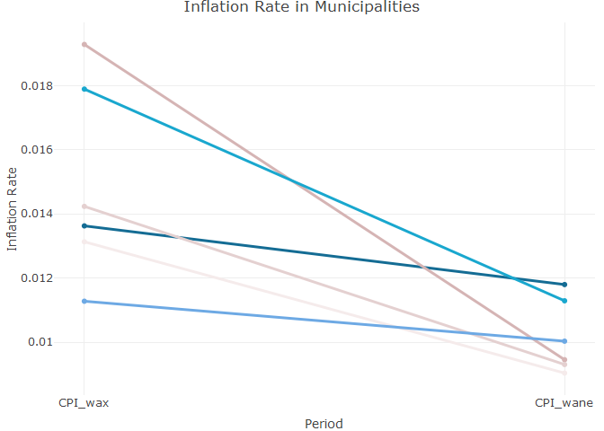

- 單獨拉出直轄市來做比較
- 以wane為標準，CPI在1%以上以藍色系標示，在1%以下則用粉色系標示
- 比較六個直轄市的兩期變化，發現到桃園市的下降幅度是最明顯的，從1.93%下降至0.95%
- 而台北市在wane時期是所有直轄市中上漲幅度最小的，只有0.9%

##### 以營業時間來討論

| business_hour | wax_cpi | wane_cpi |
| --- | --- | --- |
| breakfast | 0.0185956 | 0.0095789 |
| lunch | 0.0145903 | 0.0096474 |
| dinner | 0.0138364 | 0.0103931 |

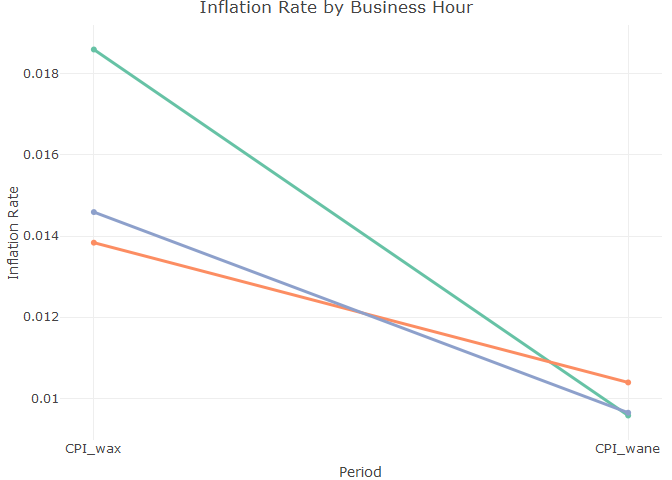

- 以早午晚餐三個時段來觀察，可以看出在蛋荒嚴重時期，早餐時段的店家之物價上漲率在1.8596%左右，是三個時段當中最高的。這是否跟早餐店需要用到大量的雞蛋有關聯?
- 蛋荒趨緩時期物價上漲率最高的則是晚餐時段的店家，約在1.0393%，而早餐時段的物價上漲率則有放緩的趨勢，來到0.9579%

##### 主計處公布之資料

###### 抓出主計處公布之外食費與其他外送平台餐廳可能所需成本(包括穀類及其製品、肉類、肉類製品、蛋類、水產品、蔬菜、食用油、調味品)的消費者物價指數，並使用2月、4月及7月資料進行比較

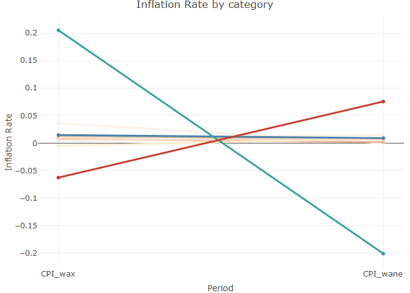

- 除了蔬菜有較高的漲幅、蛋類有明顯跌幅外，其餘種類皆無太明顯的漲跌幅。而外食費的上漲幅度也趨緩，從1.4677%降至0.8878%。